# Test octopus API

Ben Anderson

Last run at: 2022-06-15 23:05:10

# 1 Inspired by

https://www.guylipman.com/octopus/api_guide.html

and using

https://developer.octopus.energy/docs/api/#

# 2 Test without authentication

```r
# test
url <- "https://api.octopus.energy/v1/products"
message("Getting: ", url)
```

```
## Getting: https://api.octopus.energy/v1/products
```

```r
resp <- httr::GET(url)

message("Status code: ", resp$status_code)
```

```
## Status code: 200
```

```r
df <- jsonlite::parse_json(resp, simplifyVector = TRUE)
```

```
## No encoding supplied: defaulting to UTF-8.
```

```r
makeFlexTable(head(df$results), cap = "Example products list (first 6 rows)")
```

Table 2.1: Example products list (first 6 rows)

| code | direction | full_name | display_name | description | is_variable | is_green | is_tracker | is_prepay | is_business | is_restricted | term | available_from | available_to | links | brand |
| --- | --- | --- | --- | --- | --- | --- | --- | --- | --- | --- | --- | --- | --- | --- | --- |
| AFFECT-FIX-12M-22-04-21 | IMPORT | Affect 12M Fixed April 2022 v1 | Affect 12M Fixed | This tariff features 100% renewable electricity and fixes your unit rates and standing charge for 12 months. There are no exit fees, so if you change your mind, you're in control. | FALSE | FALSE | FALSE | FALSE | FALSE | FALSE | 12 | 2022-04-21T00:00:00+01:00 |  | [[data.frame]] | AFFECT_ENERGY |
| AFFECT-OCC-VAR-21-10-01 | IMPORT | Affect Occupier Standard Tariff October 2021 v1 | Affect Occupier Standard Tariff | Affect Occupier Standard Tariff offers great value and 100% renewable electricity. As a variable tariff, your prices can rise and fall with wholesale prices - but we'll always give you notice of a cha… | TRUE | FALSE | FALSE | FALSE | FALSE | FALSE |  | 2021-10-01T00:00:00+01:00 |  | [[data.frame]] | AFFECT_ENERGY |
| AFFECT-SEG-FIX-12M-20-11-11 | EXPORT | Affect Smart Export Guarantee November 2020 v1 | Affect Smart Export Guarantee | This is our Smart Export Guarantee compliant export tariff | FALSE | TRUE | FALSE | FALSE | FALSE | FALSE | 12 | 2020-11-11T17:00:00Z |  | [[data.frame]] | AFFECT_ENERGY |
| AFFECT-VAR-22-04-02 | IMPORT | Affect Standard Tariff April 2022 v1 | Affect Standard Tariff | Affect Standard Tariff offers great value and 100% renewable electricity. As a variable tariff, your prices can rise and fall with wholesale prices - but we'll always give you notice of a change, and … | TRUE | FALSE | FALSE | FALSE | FALSE | FALSE |  | 2022-03-05T00:00:00Z |  | [[data.frame]] | AFFECT_ENERGY |
| AGILE-18-02-21 | IMPORT | Agile Octopus February 2018 | Agile Octopus |  | TRUE | TRUE | FALSE | FALSE | FALSE | FALSE | 12 | 2017-01-01T00:00:00Z |  | [[data.frame]] | OCTOPUS_ENERGY |
| AGILE-OUTGOING-19-05-13 | EXPORT | Agile Outgoing Octopus May 2019 | Agile Outgoing Octopus | Outgoing Octopus Agile rate pays you for all your exported energy based on the day-ahead wholesale rate. | TRUE | TRUE | FALSE | FALSE | FALSE | FALSE | 12 | 2018-01-01T00:00:00Z |  | [[data.frame]] | OCTOPUS_ENERGY |

# 3 Tests with authentication

## 3.1 Basic info

```r
url <- paste0("https://api.octopus.energy/v1/accounts/", apiParams$accountNo , "/")

resp <- httr::GET(url = url, authenticate(user = apiParams$key, password = ""))

df <- jsonlite::parse_json(resp, simplifyVector = TRUE)
```

```
## No encoding supplied: defaulting to UTF-8.
```

```r
props <- data.table::as.data.table(df$properties)
makeFlexTable(head(props[, .(town, county,
                             electricity_meter_points,gas_meter_points)]), cap = "Properties linked to this account (non-disclosive data)")
```

Table 3.1: Properties linked to this account (non-disclosive data)

| town | county | electricity_meter_points | gas_meter_points |
| --- | --- | --- | --- |
| BRADFORD-ON-AVON | WILTSHIRE | [[data.frame]] | [[data.frame]] |
| FRAMLINGHAM |  | [[data.frame]] | [[data.frame]] |

List the electricity meter points.

```r
# this is a list of n mpans
length(props$electricity_meter_points)
```

```
## [1] 2
```

```r
message("n MPANS listed: ", length(df$properties$electricity_meter_points))
```

```
## n MPANS listed: 2
```

```r
for(n in 1:length(df$properties$electricity_meter_points)){
  print(props$electricity_meter_points[n])
}
```

```
## [[1]]
##            mpan profile_class consumption_standard
## 1 2000006198482             1                 8549
##                          meters
## 1 L78C64517, 01, STANDARD, TRUE
##                                                                                                                                                      agreements
## 1 E-1R-SUPER-GREEN-12M-20-09-22-H, E-1R-SUPER-GREEN-12M-20-09-22-H, 2020-11-01T00:00:00Z, 2020-11-21T00:00:00Z, 2020-11-01T00:00:00Z, 2021-06-30T00:00:00+01:00
##   is_export
## 1     FALSE
##
## [[1]]
##            mpan profile_class consumption_standard
## 1 1050001805886             1                 3318
##                          meters
## 1 19L3027004, 1, STANDARD, TRUE
##                                                                                                                                                    agreements
## 1 E-1R-SUPER-GREEN-12M-20-09-22-A, E-1R-LOYAL-FIX-12M-21-10-07-A, 2021-07-01T00:00:00+01:00, 2021-11-21T00:00:00Z, 2021-11-21T00:00:00Z, 2022-11-21T00:00:00Z
##   is_export
## 1     FALSE
```

```r
length(df$properties$gas_meter_points)
```

```
## [1] 2
```

```r
message("n MPRNS listed: ", length(df$properties$gas_meter_points))
```

```
## n MPRNS listed: 2
```

```r
for(n in 1:length(df$properties$gas_meter_points)){
  print(df$properties$gas_meter_points[n])
}
```

```
## [[1]]
##         mprn consumption_standard         meters
## 1 4256845702                19018 G4A01559730801
##                                                                                                                                                      agreements
## 1 G-1R-SUPER-GREEN-12M-20-09-22-H, G-1R-SUPER-GREEN-12M-20-09-22-H, 2020-11-01T00:00:00Z, 2020-11-21T00:00:00Z, 2020-11-01T00:00:00Z, 2021-06-30T00:00:00+01:00
##
## [[1]]
##         mprn consumption_standard                                       meters
## 1 7825700304                15129 E6S12725512161, E6S17944211961, NOTINSTALLED
##                                                                            agreements
## 1 G-1R-LOYAL-FIX-12M-21-10-07-A, 2021-10-04T00:00:00+01:00, 2022-10-04T00:00:00+01:00
```

## 3.2 Electricity

### 3.2.1 Consumption

See: https://www.guylipman.com/octopus/api_guide.html#s3

```r
url <- paste0("https://api.octopus.energy/v1/electricity-meter-points/",
              apiParams$elec_import_mpan , "/",
              "meters/",
              apiParams$elec_import_serial, "/",
              "consumption/",
              "?period_from=2022-01-01T00:00Z",
              "&page_size=10000")
# get data via httr ----
resp <- httr::GET(url = url, authenticate(user = apiParams$key, password = ""))
df <- jsonlite::parse_json(resp, simplifyVector = TRUE) # creates a df of which 'results' = the data
```

```
## No encoding supplied: defaulting to UTF-8.
```

```r
elecCons_dt <- data.table::as.data.table(df$results) # convert to dt

# derived variables ----
elecCons_dt <- makeDerivedVars(elecCons_dt)

maxTime <- max(elecCons_dt$dv_start)

hoursAgo <- now() - maxTime
```

The data used here is up to 2022-06-14 23:30:00, which is 22.6 hours ago. In general the Octopus API seems to have data up to `midnight last night`.

Figure 3.1 shows half-hourly electricity import (‘consumption’) for the current year. Spot the power cuts…

> To do: mark weekends somehow

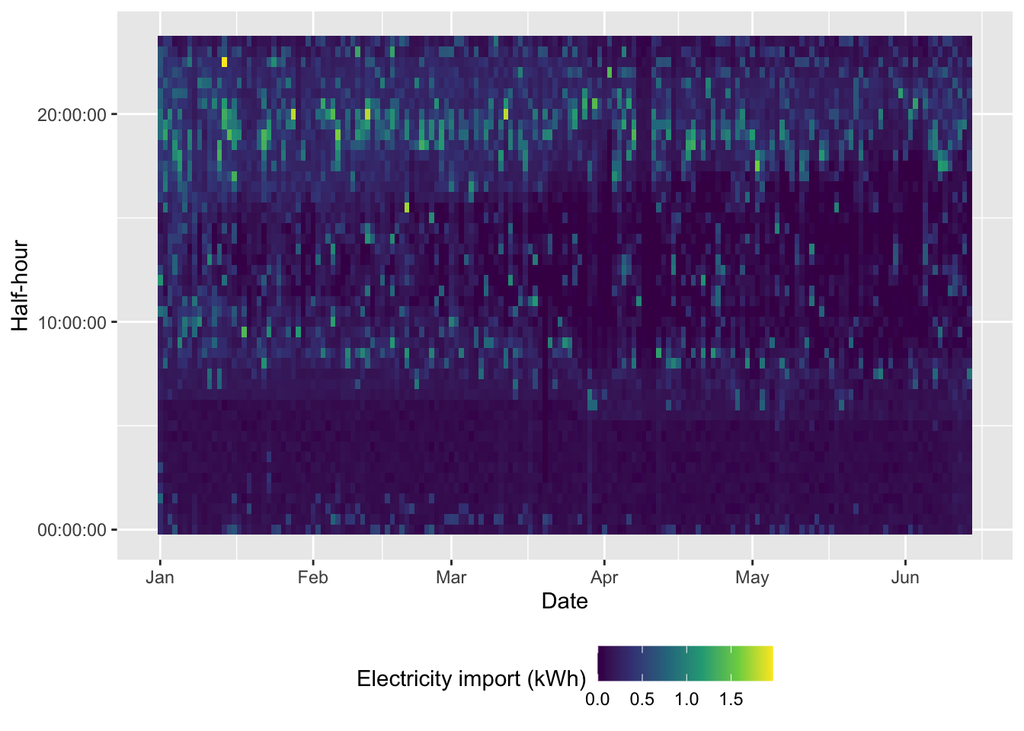

Figure 3.1: Electricity import (current year)

```r
ggplot2::ggplot(elecCons_dt, aes(x = dv_date, y = dv_hms, fill = consumption)) +
  geom_tile() +
  theme(legend.position = "bottom") +
  scale_fill_viridis_c(name = "Electricity import (kWh)") +
  labs(x = "Date",
       y = "Half-hour")
```

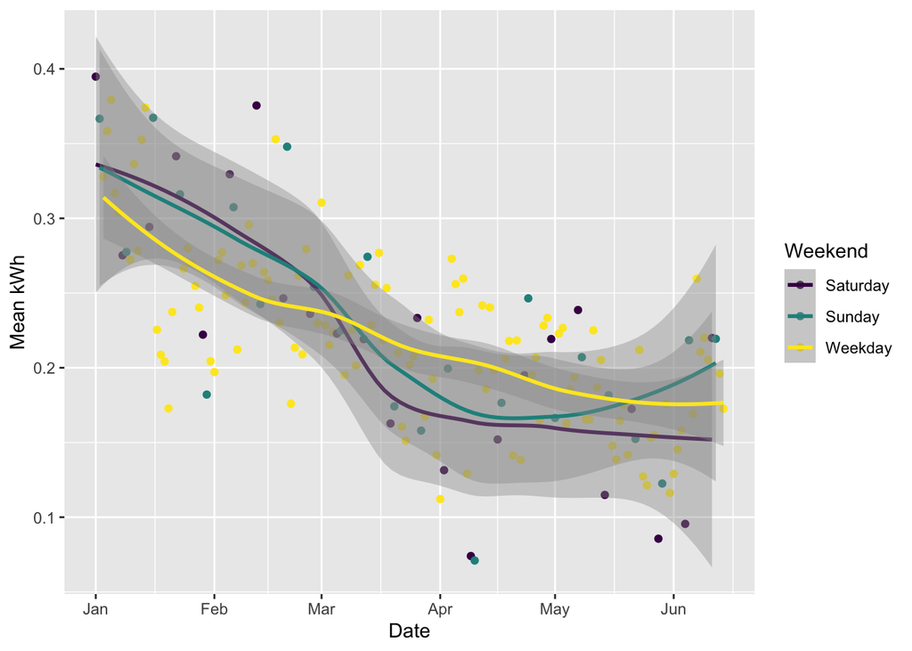

Figure 3.2: Electricity import (current year)

```r
plotDT <- elecCons_dt[, .(sum_kWh = sum(consumption),
                 mean_kWh = mean(consumption),
                 nObs = .N), keyby = .(dv_date, dv_weekend)]

ggplot2::ggplot(plotDT, aes(x = dv_date, y = mean_kWh,
                            colour = dv_weekend)) +
  geom_point() +
  geom_smooth() +
  #facet_grid(dv_peakPeriod ~ .) +
  scale_colour_viridis_d(name = "Weekend") +
  labs(x = "Date",
       y = "Mean kWh")
```

Figure 3.3 shows the mean daily kWh import with a smoothed curve for each period as defined below.

`Early morning` is effectively our baseload.

```r
# check periods
t <- elecCons_dt[, .(min = min(dv_hms),
                max = max(dv_hms)),
            keyby = .(dv_peakPeriod)]

t
```

```
##    dv_peakPeriod      min      max
## 1: Early morning 00:00:00 06:30:00
## 2:  Morning peak 07:00:00 08:30:00
## 3:      Day time 09:00:00 15:30:00
## 4:  Evening peak 16:00:00 19:30:00
## 5:  Late evening 20:00:00 23:30:00
```

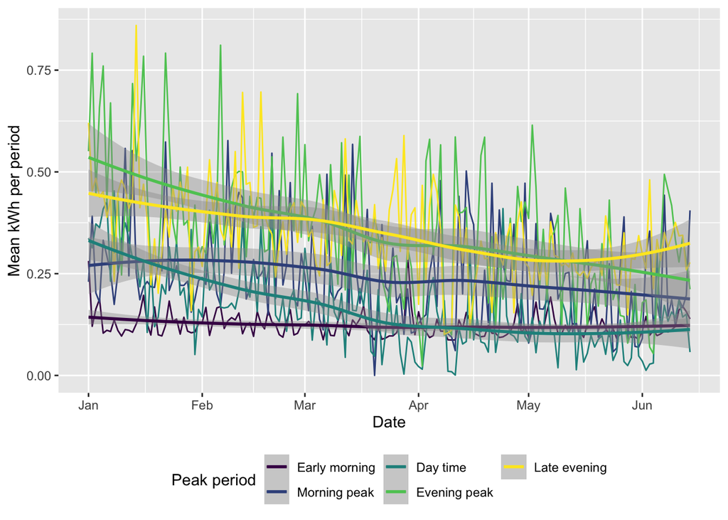

Figure 3.3: Electricity import (current year)

```r
plotDT <- elecCons_dt[, .(sum_kWh = sum(consumption),
                 mean_kWh = mean(consumption),
                 nObs = .N), keyby = .(dv_date, dv_peakPeriod, dv_weekend)]

ggplot2::ggplot(plotDT, aes(x = dv_date, y = mean_kWh,
                            colour = dv_peakPeriod)) +
  geom_line() +
  geom_smooth() +
  #facet_grid(dv_peakPeriod ~ .) +
  theme(legend.position = "bottom") +
  guides(colour = guide_legend (ncol = 3)) +
  scale_colour_viridis_d(name = "Peak period") +
  labs(x = "Date",
       y = "Mean kWh per period")
```

### 3.2.2 Export

This will be a new MPAN but specified as export - although the url will still say `consumption`. We do not have this even though the PV is exporting on (some) days.

It may be that we only get this data if we sign up for the export tariff.

See https://www.guylipman.com/octopus/api_guide.html#s3

## 3.3 Gas Consumption

```r
url <- paste0("https://api.octopus.energy/v1/gas-meter-points/",
              apiParams$gas_mpan , "/",
              "meters/",
              apiParams$gas_serial, "/",
              "consumption",
              "?period_from=2022-01-01T00:00Z",
              "&page_size=10000")
resp <- httr::GET(url = url, authenticate(user = apiParams$key, password = ""))
df <- jsonlite::parse_json(resp, simplifyVector = TRUE)
```

```
## No encoding supplied: defaulting to UTF-8.
```

```r
gasCons_dt <- data.table::as.data.table(df$results)
gasCons_dt <- makeDerivedVars(gasCons_dt)
```

Note that this data starts later as we finally got the original un-registered smart meter replaced in February.

Figure 3.4 shows half-hourly gas import (‘consumption’) for the current year. The power cuts are even easier to see here. Interestingly the pattern after the gas boiler was serviced in June is more varied. *What did he change*?

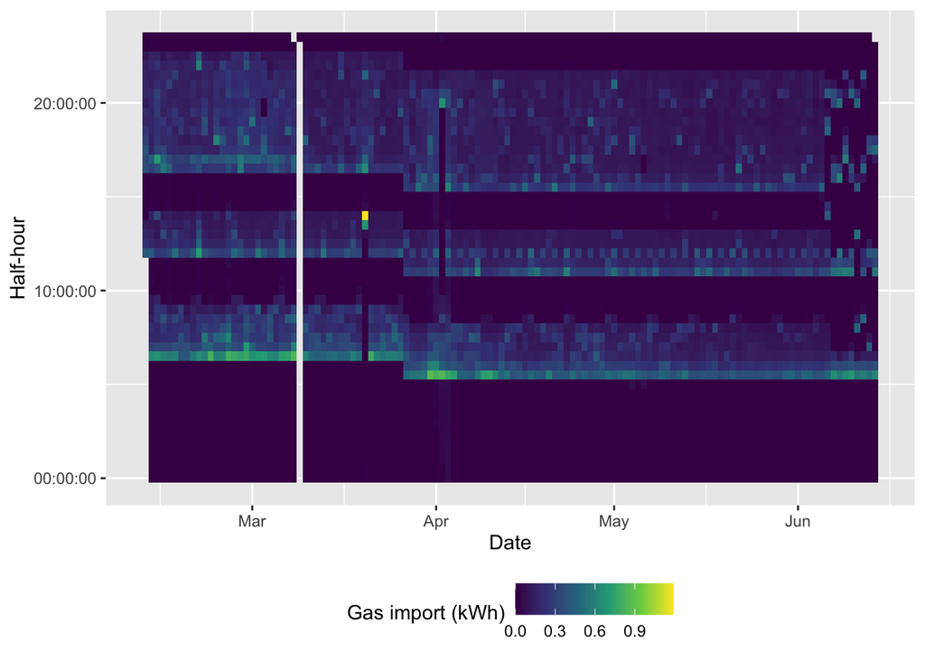

Figure 3.4: Gas consumption (current year)

```r
ggplot2::ggplot(gasCons_dt, aes(x = dv_date, y = dv_hms, fill = consumption)) +
  geom_tile() +
  theme(legend.position = "bottom") +
  scale_fill_viridis_c(name = "Gas import (kWh)") +
  labs(x = "Date",
       y = "Half-hour")
```

> To do: mark weekends etc

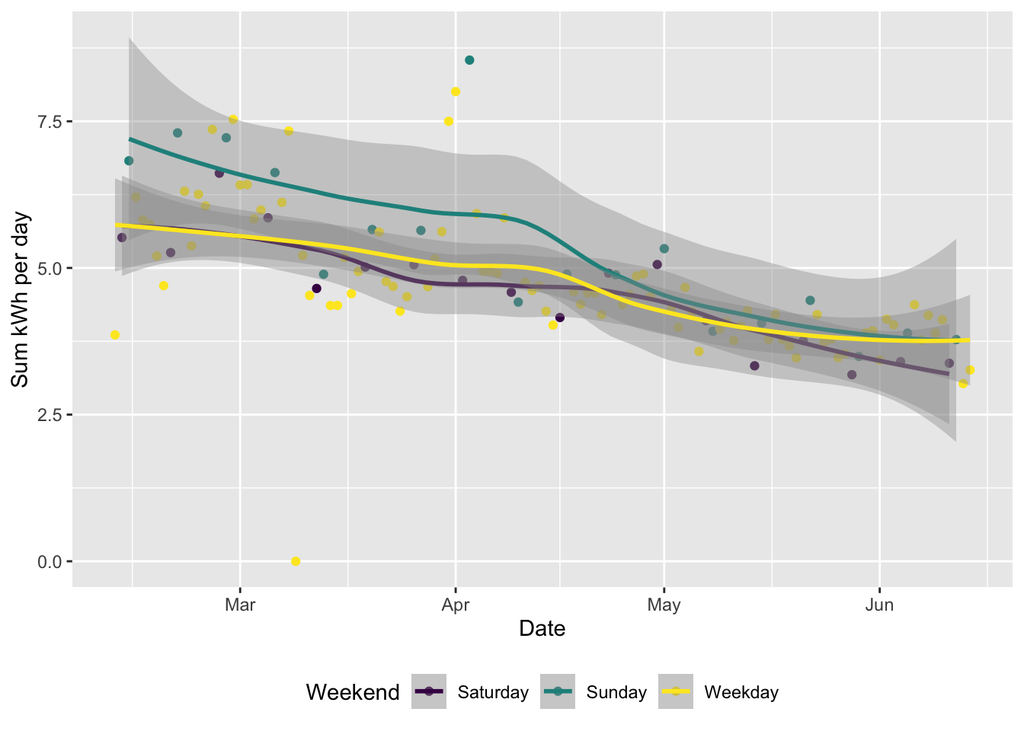

```r
plotDT <- gasCons_dt[, .(sum_kWh = sum(consumption),
                 mean_kWh = mean(consumption),
                 nObs = .N), keyby = .(dv_date, dv_weekend)]

ggplot2::ggplot(plotDT, aes(x = dv_date, y = sum_kWh,
                            colour = dv_weekend)) +
  geom_point() +
  geom_smooth() +
  theme(legend.position = "bottom") +
  guides(colour = guide_legend (ncol = 3)) +
  scale_colour_viridis_d(name = "Weekend") +
  labs(x = "Date",
       y = "Sum kWh per day")
```

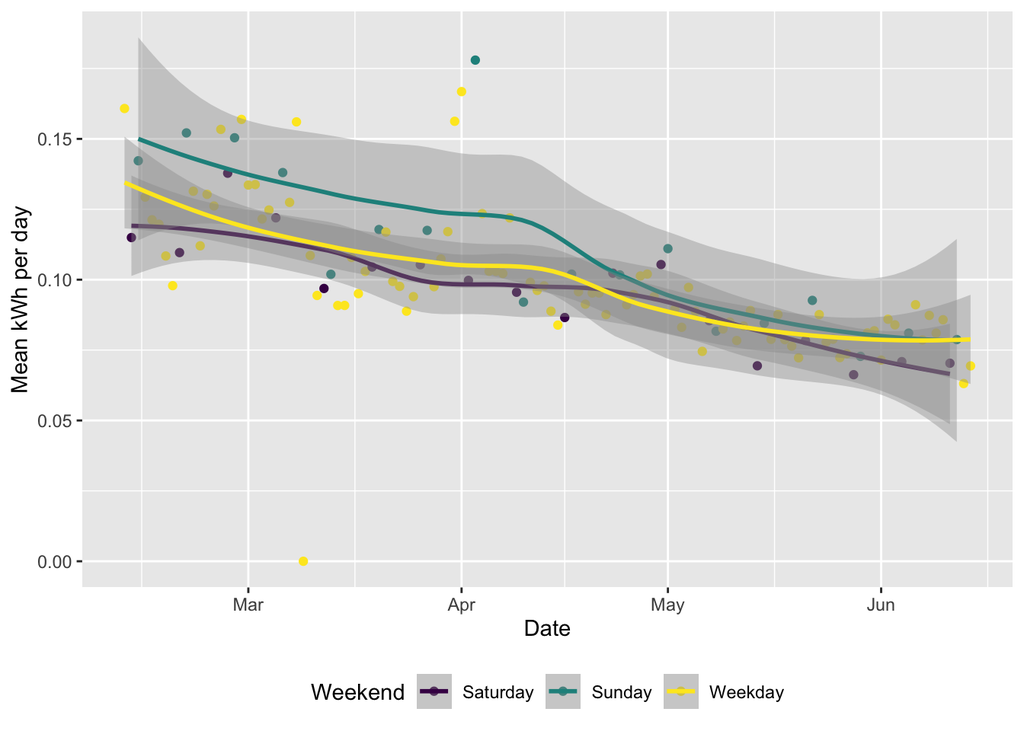

```r
ggplot2::ggplot(plotDT, aes(x = dv_date, y = mean_kWh,
                            colour = dv_weekend)) +
  geom_point() +
  geom_smooth() +
  theme(legend.position = "bottom") +
  guides(colour = guide_legend (ncol = 3)) +
  scale_colour_viridis_d(name = "Weekend") +
  labs(x = "Date",
       y = "Mean kWh per day")
```

Figure 3.7 shows the mean daily kWh import with a smoothed curve by period of the day.

> To do: mark weekends etc

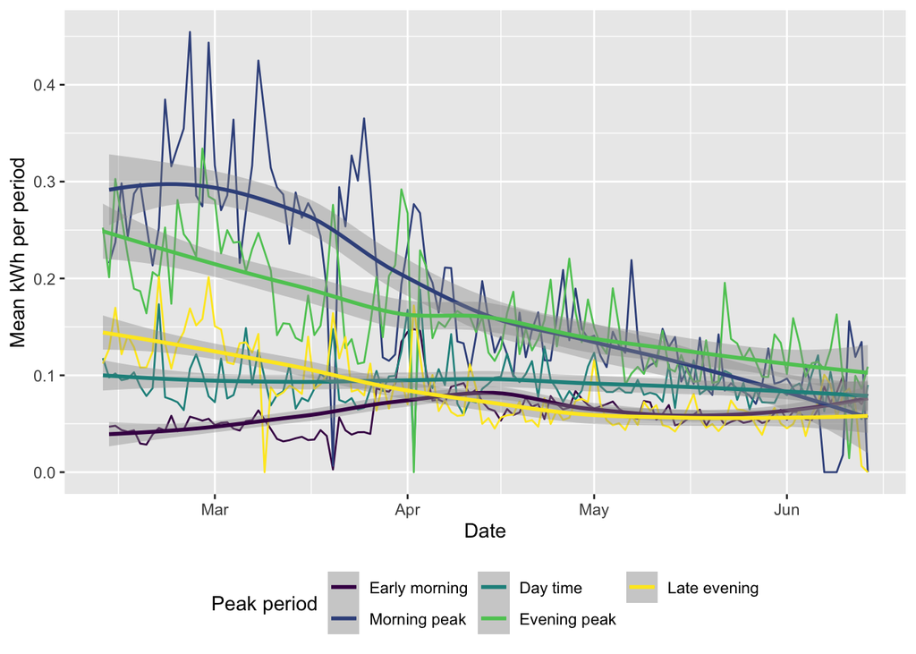

```r
plotDT <- gasCons_dt[, .(sum_kWh = sum(consumption),
                 mean_kWh = mean(consumption),
                 nObs = .N), keyby = .(dv_date, dv_peakPeriod, dv_weekend)]

ggplot2::ggplot(plotDT, aes(x = dv_date, y = mean_kWh,
                            colour = dv_peakPeriod)) +
  geom_line() +
  geom_smooth() +
  #facet_grid(dv_peakPeriod ~ .) +
  theme(legend.position = "bottom") +
  guides(colour = guide_legend (ncol = 3)) +
  scale_colour_viridis_d(name = "Peak period") +
  labs(x = "Date",
       y = "Mean kWh per period")
```

# 4 Annexes

## 4.1 Data descriptions

### 4.1.1 Electricity consumption

Use `skmir::skim()`to summarise.

```r
skimr::skim(elecCons_dt)
```

Table 4.1: Data summary

| Name | elecCons_dt |
| --- | --- |
| Number of rows | 7920 |
| Number of columns | 8 |
| Key | NULL |
| _______________________ |  |
| Column type frequency: |  |
| character | 3 |
| Date | 1 |
| difftime | 1 |
| factor | 1 |
| numeric | 1 |
| POSIXct | 1 |
| ________________________ |  |
| Group variables | None |

**Variable type: character**

| skim_variable | n_missing | complete_rate | min | max | empty | n_unique | whitespace |
| --- | --- | --- | --- | --- | --- | --- | --- |
| interval_start | 0 | 1 | 20 | 25 | 0 | 7920 | 0 |
| interval_end | 0 | 1 | 20 | 25 | 0 | 7920 | 0 |
| dv_weekend | 0 | 1 | 6 | 8 | 0 | 3 | 0 |

**Variable type: Date**

| skim_variable | n_missing | complete_rate | min | max | median | n_unique |
| --- | --- | --- | --- | --- | --- | --- |
| dv_date | 0 | 1 | 2022-01-01 | 2022-06-14 | 2022-03-24 | 165 |

**Variable type: difftime**

| skim_variable | n_missing | complete_rate | min | max | median | n_unique |
| --- | --- | --- | --- | --- | --- | --- |
| dv_hms | 0 | 1 | 0 secs | 84600 secs | 42300 secs | 48 |

**Variable type: factor**

| skim_variable | n_missing | complete_rate | ordered | n_unique | top_counts |
| --- | --- | --- | --- | --- | --- |
| dv_peakPeriod | 0 | 1 | FALSE | 5 | Ear: 2310, Day: 2310, Eve: 1320, Lat: 1320 |

**Variable type: numeric**

| skim_variable | n_missing | complete_rate | mean | sd | p0 | p25 | p50 | p75 | p100 | hist |
| --- | --- | --- | --- | --- | --- | --- | --- | --- | --- | --- |
| consumption | 0 | 1 | 0.22 | 0.22 | 0 | 0.09 | 0.14 | 0.28 | 1.97 | ▇▁▁▁▁ |

**Variable type: POSIXct**

| skim_variable | n_missing | complete_rate | min | max | median | n_unique |
| --- | --- | --- | --- | --- | --- | --- |
| dv_start | 0 | 1 | 2022-01-01 | 2022-06-14 23:30:00 | 2022-03-24 11:45:00 | 7920 |

### 4.1.2 Gas consumption

Use `skmir::skim()`to summarise.

```r
skimr::skim(gasCons_dt)
```

Table 4.2: Data summary

| Name | gasCons_dt |
| --- | --- |
| Number of rows | 5879 |
| Number of columns | 8 |
| Key | NULL |
| _______________________ |  |
| Column type frequency: |  |
| character | 3 |
| Date | 1 |
| difftime | 1 |
| factor | 1 |
| numeric | 1 |
| POSIXct | 1 |
| ________________________ |  |
| Group variables | None |

**Variable type: character**

| skim_variable | n_missing | complete_rate | min | max | empty | n_unique | whitespace |
| --- | --- | --- | --- | --- | --- | --- | --- |
| interval_start | 0 | 1 | 20 | 25 | 0 | 5879 | 0 |
| interval_end | 0 | 1 | 20 | 25 | 0 | 5879 | 0 |
| dv_weekend | 0 | 1 | 6 | 8 | 0 | 3 | 0 |

**Variable type: Date**

| skim_variable | n_missing | complete_rate | min | max | median | n_unique |
| --- | --- | --- | --- | --- | --- | --- |
| dv_date | 0 | 1 | 2022-02-11 | 2022-06-14 | 2022-04-14 | 124 |

**Variable type: difftime**

| skim_variable | n_missing | complete_rate | min | max | median | n_unique |
| --- | --- | --- | --- | --- | --- | --- |
| dv_hms | 0 | 1 | 0 secs | 84600 secs | 12:00:00 | 48 |

**Variable type: factor**

| skim_variable | n_missing | complete_rate | ordered | n_unique | top_counts |
| --- | --- | --- | --- | --- | --- |
| dv_peakPeriod | 0 | 1 | FALSE | 5 | Day: 1716, Ear: 1708, Eve: 984, Lat: 983 |

**Variable type: numeric**

| skim_variable | n_missing | complete_rate | mean | sd | p0 | p25 | p50 | p75 | p100 | hist |
| --- | --- | --- | --- | --- | --- | --- | --- | --- | --- | --- |
| consumption | 0 | 1 | 0.1 | 0.13 | 0 | 0 | 0.02 | 0.16 | 1.19 | ▇▁▁▁▁ |

**Variable type: POSIXct**

| skim_variable | n_missing | complete_rate | min | max | median | n_unique |
| --- | --- | --- | --- | --- | --- | --- |
| dv_start | 0 | 1 | 2022-02-11 12:00:00 | 2022-06-14 23:00:00 | 2022-04-14 17:30:00 | 5879 |

# 5 References